# Lambda inflation of GWAS->CpG levels

Get sample sizes

```r
suppressWarnings(suppressPackageStartupMessages({
    library(knitr)
    library(dplyr)
    library(ggplot2)
    library(ggrepel)
    library(tidyr)
}))
opts_chunk$set(cache=TRUE, echo=TRUE, message=FALSE, warning=FALSE)
load("../results/lambda.rdata")
load("../data/traitlist.rdata")
```

Is there a general influence of a single trait having an influence on large numbers of CpGs? To test this calculate the lambda value for the MR p-values of trait->CpG scan. This should be done on MR estimates that exclude any chromosome 6 instruments.

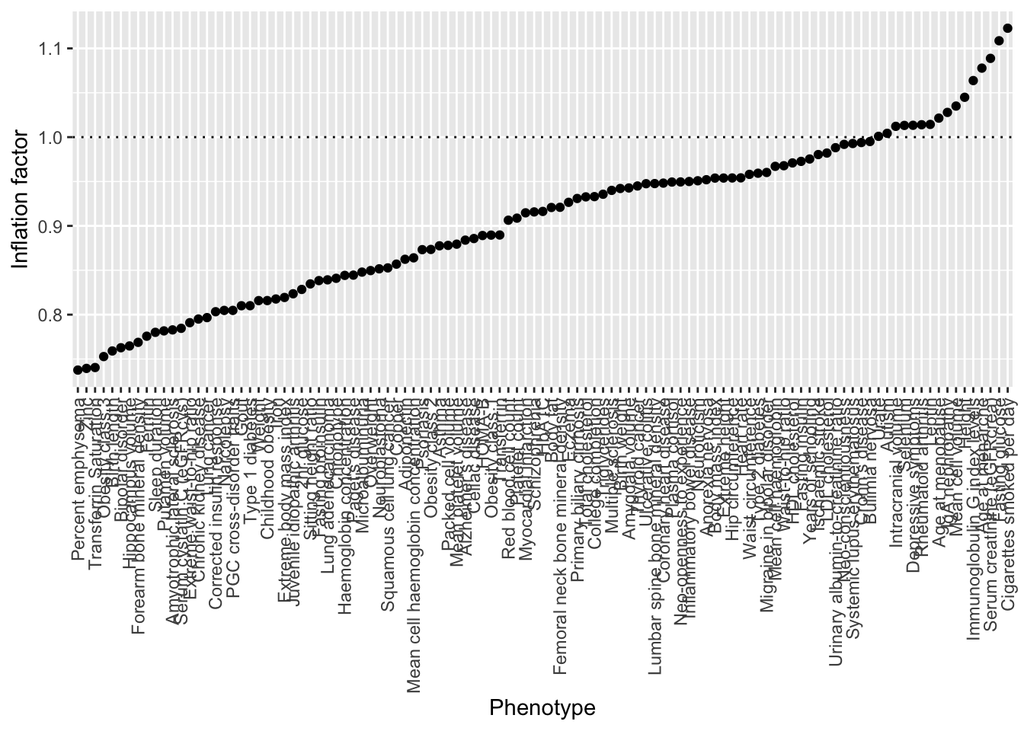

```r
ggplot(lamb %>% arrange(lambda), aes(x=phen, y=lambda)) +
geom_point() +
geom_hline(yintercept=1, linetype="dotted") +
theme(axis.text.x=element_text(angle=90, hjust=1, vjust=0.5)) +
labs(x="Phenotype", y="Inflation factor")
```

```r
ggsave("../images/lambda.pdf", width=15, height=8)
```

Also calculate the proportion of MR effect estimates that are positive. If there is substantial over or under representation of positive MR estimates then it indicates that there is a general directionality of that trait on the methylation levels.

```r
table(lam$pdir < 0.05)
```

```
##
## FALSE  TRUE
##     3   251
```

This level of imbalance is strange - not sure why majority would be more than expected.

There is not a particularly strong relationship between directional enrichment and lambda

```r
summary(lm(lambda ~ I(abs(0.5 - proppos)), lamb))
```

```
##
## Call:
## lm(formula = lambda ~ I(abs(0.5 - proppos)), data = lamb)
##
## Residuals:
##       Min        1Q    Median        3Q       Max
## -0.166056 -0.077949  0.009785  0.063180  0.197222
##
## Coefficients:
##                       Estimate Std. Error t value Pr(>|t|)
## (Intercept)            0.88353    0.01568  56.333   <2e-16 ***
## I(abs(0.5 - proppos))  0.47780    0.28869   1.655    0.101
## ---
## Signif. codes:  0 '***' 0.001 '**' 0.01 '*' 0.05 '.' 0.1 ' ' 1
##
## Residual standard error: 0.08935 on 107 degrees of freedom
## Multiple R-squared:  0.02496,    Adjusted R-squared:  0.01585
## F-statistic: 2.739 on 1 and 107 DF,  p-value: 0.1008
```

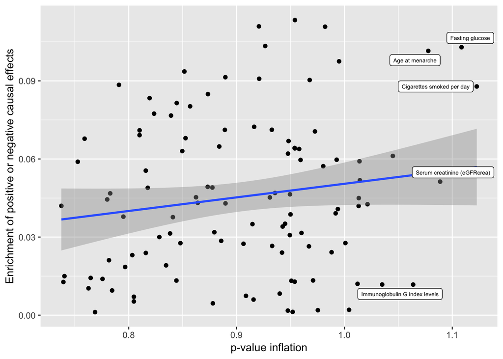

```r
lamb$imbalance <- abs(lamb$proppos - 0.5)
ggplot(lamb, aes(x=lambda, y=imbalance)) +
geom_point() +
geom_smooth(method="lm") +
geom_label_repel(data=subset(lamb, lambda > 1.05), aes(label=phen), size=2) +
labs(x="p-value inflation", y="Enrichment of positive or negative causal effects")
```

```r
ggsave("../images/lambda_vs_imbalance.pdf")
```

Is there a higher number of significant associations for higher lambda values?

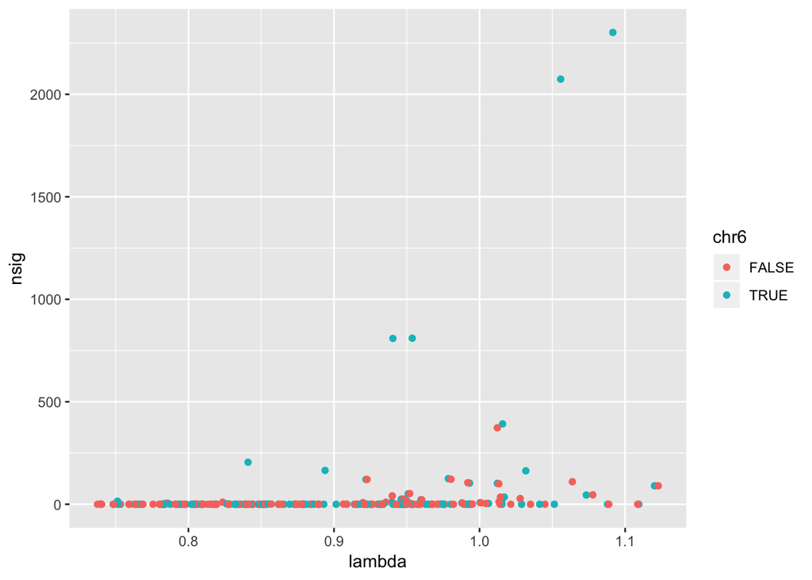

```r
ggplot(lam, aes(x=lambda, y=nsig)) +
geom_point(aes(colour=chr6))
```

```r
summary(lm(nsig ~ lambda, lam))
```

```
##
## Call:
## lm(formula = nsig ~ lambda, data = lam)
##
## Residuals:
##     Min      1Q  Median      3Q     Max
## -151.32  -62.00  -23.32   15.65 2160.54
##
## Coefficients:
##             Estimate Std. Error t value Pr(>|t|)
## (Intercept)   -461.9      130.9  -3.528 0.000497 ***
## lambda         552.7      144.7   3.820 0.000168 ***
## ---
## Signif. codes:  0 '***' 0.001 '**' 0.01 '*' 0.05 '.' 0.1 ' ' 1
##
## Residual standard error: 204.3 on 252 degrees of freedom
## Multiple R-squared:  0.05474,    Adjusted R-squared:  0.05099
## F-statistic: 14.59 on 1 and 252 DF,  p-value: 0.000168
```

## Look at highest lambda values

Which traits have high lambda values?

```r
kable(lambtop)
```

| id | chr6 | ncpg | nsnp | minp | nsig | lambda | proppos | pdir | trait | phen | imbalance |
| --- | --- | --- | --- | --- | --- | --- | --- | --- | --- | --- | --- |
| 100 | FALSE | 317659 | 1 | 0.0e+00 | 90 | 1.122726 | 0.5878505 | 0 | Cigarettes smoked per day \|\| TAG \|\| 2010 \|\| Cigarettes per day | Cigarettes smoked per day | 0.0878505 |
| 20 | FALSE | 317659 | 34 | 1.4e-06 | 0 | 1.108604 | 0.3970673 | 0 | Fasting glucose \|\| MAGIC \|\| 2012 \|\| mmol/L | Fasting glucose | 0.1029327 |
| 19 | FALSE | 317659 | 43 | 5.7e-06 | 0 | 1.088766 | 0.5512893 | 0 | Serum creatinine (eGFRcrea) \|\| CKDGen \|\| 2015 \|\| log ml/min/1.73 m^² | Serum creatinine (eGFRcrea) | 0.0512893 |
| 32 | FALSE | 317659 | 65 | 0.0e+00 | 46 | 1.077760 | 0.6015192 | 0 | Age at menarche \|\| ReproGen \|\| 2014 \|\| years | Age at menarche | 0.1015192 |
| 91 | FALSE | 317659 | 1 | 0.0e+00 | 110 | 1.063746 | 0.5117500 | 0 | Immunoglobulin G index levels \|\| NA \|\| 2015 \|\| log2 IgG index ratio | Immunoglobulin G index levels | 0.0117500 |

What if we take random subsets of CpGs, can we make sure it is not some outliers pushing up the lambda value (this is not likely cos it’s based on median)

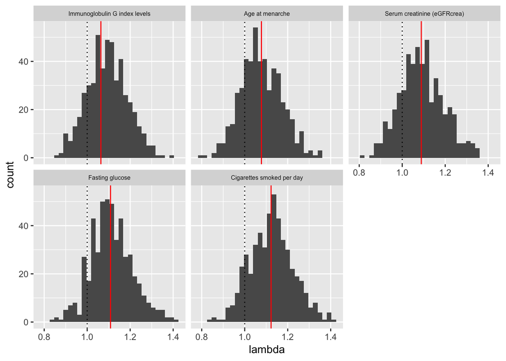

```r
ggplot(lambdatop, aes(x=lambda)) +
geom_histogram() +
geom_vline(data=lambtop, aes(xintercept=lambda), colour="red") +
geom_vline(xintercept=1, linetype="dotted") +
facet_wrap(~ phen) +
theme(strip.text=element_text(size=6))
```

```r
ggsave("../images/lambda_top.pdf")
```

Lambda by chromosome

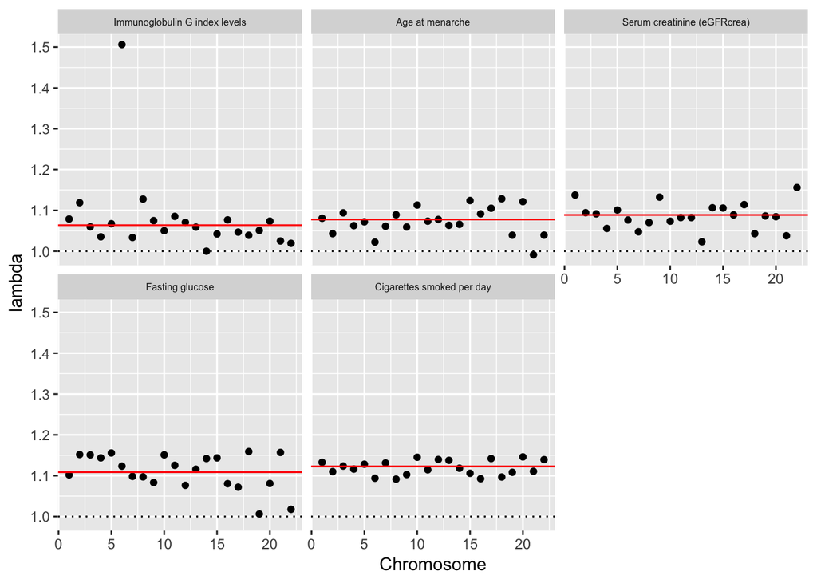

```r
ggplot(lambdatopchr %>% filter(n > 500), aes(y=lambda, x=gsub("chr", "", chr) %>% as.numeric)) +
geom_point() +
geom_hline(data=lambtop, aes(yintercept=lambda), colour="red") +
geom_hline(yintercept=1, linetype="dotted") +
facet_wrap(~ phen) +
theme(strip.text=element_text(size=6)) +
labs(x="Chromosome")
```

```r
ggsave("../images/lambda_top_chr.pdf")
```

```r
subset(lam, grepl("Immuno", trait), select=-c(trait)) %>% kable
```

|  | id | chr6 | ncpg | nsnp | minp | nsig | lambda | proppos | pdir | phen |
| --- | --- | --- | --- | --- | --- | --- | --- | --- | --- | --- |
| 181 | 91 | TRUE | 345109 | 1 | 0 | 2302 | 1.091544 | 0.5106329 | 0 | Immunoglobulin G index levels |
| 182 | 91 | FALSE | 317659 | 1 | 0 | 110 | 1.063746 | 0.5117500 | 0 | Immunoglobulin G index levels |

After leave-one-chromsome-out analysis is the lambda value staying large?

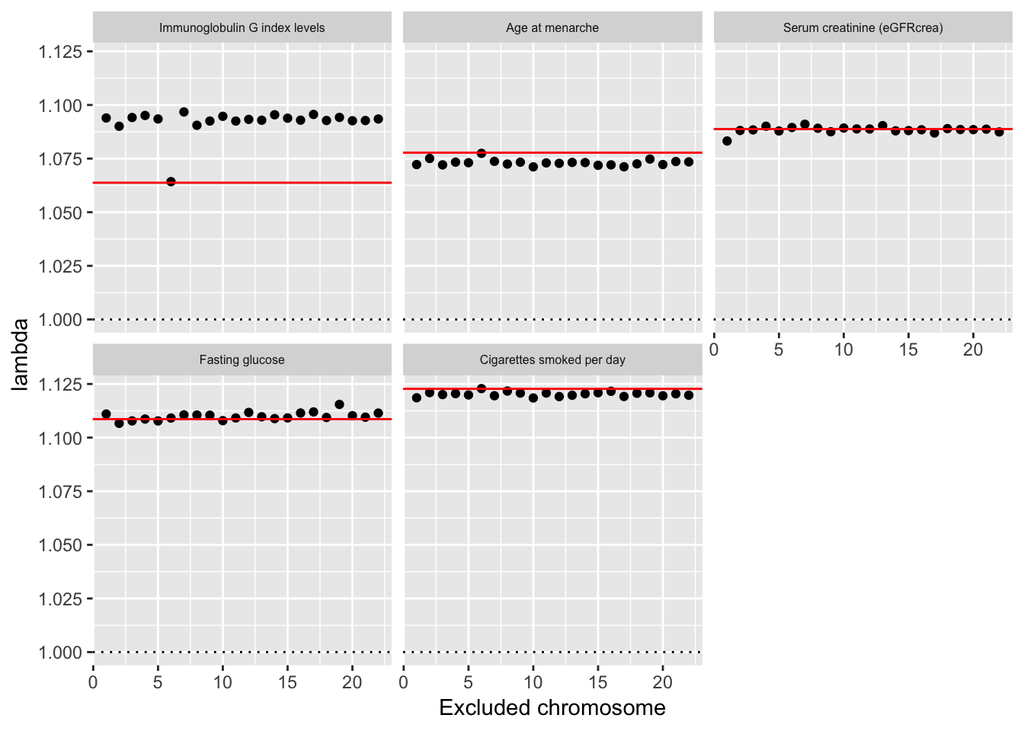

```r
ggplot(lambdatoploo %>% filter(n > 500), aes(y=lambda, x=chr)) +
geom_point() +
geom_hline(data=lambtop, aes(yintercept=lambda), colour="red") +
geom_hline(yintercept=1, linetype="dotted") +
facet_wrap(~ phen) +
theme(strip.text=element_text(size=6)) +
labs(x="Excluded chromosome")
```

```r
ggsave("../images/lambda_top_loo.pdf")
```

## EWAS hits

For some traits, the EWAS hits might show higher GWAS->CpG MR values than all CpGs in general.

```r
kable(ewas_lambda)
```

| trait | jid | lambda_full | ewas_hits | lambda_ewas | fisher_ewas |
| --- | --- | --- | --- | --- | --- |
| 28194238 High-density lipoprotein cholesterol | 22 | 0.9669477 | 47 | 1.4505710 | 0.0000134 |
| 28194238 Total cholesterol | 23 | 0.9300369 | 4 | 2.9039144 | 0.0176923 |
| 28213390 Serum low-density lipoprotein cholesterol | 24 | 0.9801891 | 31 | 0.6755807 | 0.2424738 |
| 28194238 Triglycerides | 21 | 0.9397744 | 10 | 45.7302610 | 0.0000000 |
| 28002404 Body mass index | 7 | 0.9544620 | 273 | 3.2029754 | 0.0000000 |
| Cigarettes per day | 100 | 1.1201662 | 11267 | 1.0961181 | 0.0000000 |